# Econometrics - Homework 2

# Name: Hakon Petermann Rueda

```r
#loading data
prospect_data <- read.csv("prospects.csv")
credit_data <- read.csv("credit.csv")
#View(prospect_data)
#View(credit_data)

#class(credit_data$home)
#is.vector(credit_data$home)


credit_data$home_vector <- as.factor(credit_data$home)
# #class(credit_data$home_vector)
 levels(credit_data$home_vector)
```

```
[1] "ignore"  "other"   "owner"   "parents" "priv"    "rent"
```

```r
# nlevels(credit_data$home_vector)
#
credit_data$marital_vector <- as.factor(credit_data$marital)
# #class(credit_data$marital_vector)
# levels(credit_data$marital_vector)
# nlevels(credit_data$marital_vector)
#
credit_data$job_vector <- as.factor(credit_data$job)
# #class(credit_data$job_vector)
# levels(credit_data$job_vector)
# nlevels(credit_data$job_vector)


prospect_data$home_vector <- as.factor(prospect_data$home)
prospect_data$marital_vector <- as.factor(prospect_data$marital)
prospect_data$job_vector <- as.factor(prospect_data$job)
```

Description of the variables in both data sets: - `seniority` job seniority (years) - `home` type of home ownership - `age` client’s age - `marital` marital status - `job` type of job - `expenses` client’s expenses - `income` client’s income - `assets` client’s assets - `debt` client’s existing debts - `amount` loan amount (for prospects, this is the personal loan amount they have applied for) - `savings` client’s savings

Correlations

```r
#ggp <- ggpairs(credit_data[,c("default", "seniority", "home", "age", "marital", "job", "expenses", "income", "assets", "debt", "amount", "savings")])
#print(ggp, progress = FALSE)

correlations <- cor(credit_data[,c("default", "seniority", "age", "expenses", "income", "assets", "debt", "amount", "savings")])
print(correlations)
```

```
              default    seniority         age    expenses     income      assets         debt       amount      savings
default    1.00000000 -0.259741932 -0.09530545  0.02963339 -0.1443621 -0.09723900  0.010407501  0.154325363 -0.185516302
seniority -0.25974193  1.000000000  0.50608874  0.12568047  0.1212241  0.12424073 -0.019346612 -0.007639347  0.093245570
age       -0.09530545  0.506088738  1.00000000  0.24813694  0.1475565  0.18098586 -0.046187886  0.029030782  0.062036053
expenses   0.02963339  0.125680475  0.24813694  1.00000000  0.2550052  0.01893457  0.014770828  0.049539122 -0.038093953
income    -0.14436215  0.121224109  0.14755649  0.25500519  1.0000000  0.21911198  0.144696747  0.190820113  0.717962960
assets    -0.09723900  0.124240730  0.18098586  0.01893457  0.2191120  1.00000000  0.191619494  0.144283763  0.067001079
debt       0.01040750 -0.019346612 -0.04618789  0.01477083  0.1446967  0.19161949  1.000000000  0.050902247  0.004990088
amount     0.15432536 -0.007639347  0.02903078  0.04953912  0.1908201  0.14428376  0.050902247  1.000000000 -0.149323056
savings   -0.18551630  0.093245570  0.06203605 -0.03809395  0.7179630  0.06700108  0.004990088 -0.149323056  1.000000000
```

# 1. Build and estimate a model to predict the probability that these applicants will default on their loan (if you choose to disburse one).

## i. Write down a sensible model; explain your economic intuition for including the variables on the right-hand side of this model.

I would include most variables in the dataset. Two explanatory variables jump out as potentially being highly correlated, and this is confirmed when generating a correlation table: job *seniority* & *age*, as well as *savings level* & *income*. I will take out *age*, and *income* then because both *seniority* and *savings* have higher correlations with defaulting.

I also think that home ownership type might be correlated very highly with savings rate, and so will be removing it (i.e., those living with their parents will intuitively have less savings then home owners).

As for the rest of the numeric variables, my economic intuition says that it doesn’t hurt to include them all. And for the factor variables, the same applies because there could be some hidden interactions behind the data that we do not expect. For example, marital status, or job contract type might be good predictors for default probability, but my intuition would not expect will be too highly correlated with other explanatory variables.

Estimated model: default ~ seniority + marital + job + expenses + assets + debt + amount + savings

## ii. Estimate this model using:

### a. Linear Probability Model

```r
model_lm1 <- lm(default ~ seniority + marital + job_vector + expenses + assets + debt + amount + savings, data = credit_data) #as described above
model_lm2 <- lm(default ~ seniority + home + job + expenses + assets + debt + amount + savings, data = credit_data) #removed marital vector due to insignificance, added home vector instead
model_lm3 <- lm(default ~ seniority + job + expenses + assets + debt + amount + savings, data = credit_data) #removed both martial and home vector
model_lm4 <- lm(default ~ seniority + job + expenses + assets + amount + savings, data = credit_data) #removed debt due to statistical insignificance

stargazer(model_lm1, model_lm2, model_lm3, model_lm4, type = 'text')
```

[output not shown]

```
==========================================================================================================================
                                                             Dependent variable:
                    ------------------------------------------------------------------------------------------------------
                                                                   default
                               (1)                       (2)                      (3)                       (4)
--------------------------------------------------------------------------------------------------------------------------
seniority                   -0.010***                 -0.009***                -0.010***                 -0.010***
                             (0.001)                   (0.001)                  (0.001)                   (0.001)

maritalmarried              -0.145**
                             (0.067)

maritalseparated              0.121
                             (0.075)

maritalsingle                -0.086
                             (0.068)

maritalwidow                 -0.053
                             (0.084)

job_vectorfreelance         0.112***
                             (0.015)

job_vectorothers            0.146***
                             (0.034)

job_vectorpartime           0.314***
                             (0.022)

homeother                                               0.053
                                                       (0.094)

homeowner                                              -0.164*
                                                       (0.091)

homeparents                                            -0.115
                                                       (0.092)

homepriv                                               -0.046
```

[output cut: 25 more lines]

```

savings                     -0.013***                 -0.013***                -0.013***                 -0.013***
                             (0.002)                   (0.002)                  (0.002)                   (0.002)

Constant                    0.218***                  0.257***                  0.151***                 0.153***
                             (0.071)                   (0.095)                  (0.026)                   (0.026)

--------------------------------------------------------------------------------------------------------------------------
Observations                  4,446                     4,446                    4,446                     4,446
R2                            0.174                     0.188                    0.163                     0.162
Adjusted R2                   0.171                     0.185                    0.161                     0.161
Residual Std. Error     0.409 (df = 4432)         0.406 (df = 4431)        0.412 (df = 4436)         0.412 (df = 4437)
F Statistic         71.702*** (df = 13; 4432) 73.256*** (df = 14; 4431) 95.701*** (df = 9; 4436) 107.372*** (df = 8; 4437)
==========================================================================================================================
Note:                                                                                          *p<0.1; **p<0.05; ***p<0.01
```

Before settling on a final model, I would like to consider adding the home owner variable, as that model has the highest adjusted-R2, but I am worried that is simply due to correlation with savings rate (i.e., multicollinearity is present.). Let me use a boxplot to see this relationship visually:

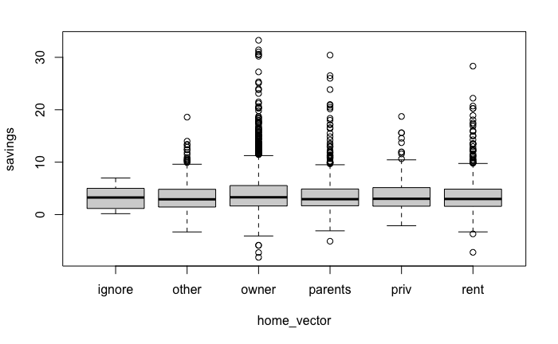

```r
#aov1 = aov(savings ~ home_vector, data = credit_data)
#summary(aov1)
#?boxplot
boxplot(savings ~ home_vector, data = credit_data)
```

It seems that there is not a strong relationship as I expected. I was not totally wrong as the biggest and most outliers for those with the highest savings are the home owners, but those are only outliers, and they are present for the other catagories too.

Therefore my final model will be:

default ~ seniority + home + job + expenses + assets + debt + amount + savings

```r
#summary of chosen model
summary(model_lm2)
```

```
Call:
lm(formula = default ~ seniority + home + job + expenses + assets +
    debt + amount + savings, data = credit_data)

Residuals:
    Min      1Q  Median      3Q     Max
-0.8423 -0.2844 -0.1436  0.3563  1.3551

Coefficients:
               Estimate Std. Error t value Pr(>|t|)
(Intercept)   2.570e-01  9.470e-02   2.714  0.00668 **
seniority    -9.016e-03  8.131e-04 -11.088  < 2e-16 ***
homeother     5.286e-02  9.363e-02   0.565  0.57236
homeowner    -1.639e-01  9.132e-02  -1.795  0.07279 .
homeparents  -1.151e-01  9.208e-02  -1.250  0.21142
homepriv     -4.608e-02  9.445e-02  -0.488  0.62570
homerent     -7.835e-03  9.182e-02  -0.085  0.93200
jobfreelance  1.166e-01  1.531e-02   7.614 3.22e-14 ***
jobothers     1.509e-01  3.284e-02   4.595 4.45e-06 ***
jobpartime    3.066e-01  2.156e-02  14.219  < 2e-16 ***
expenses      7.734e-04  3.408e-04   2.269  0.02331 *
assets       -2.758e-06  5.768e-07  -4.782 1.79e-06 ***
debt          1.456e-05  5.072e-06   2.872  0.00410 **
amount        1.406e-04  1.323e-05  10.632  < 2e-16 ***
savings      -1.259e-02  1.679e-03  -7.500 7.67e-14 ***
---
Signif. codes:  0 ‘***’ 0.001 ‘**’ 0.01 ‘*’ 0.05 ‘.’ 0.1 ‘ ’ 1

Residual standard error: 0.4057 on 4431 degrees of freedom
Multiple R-squared:  0.188, Adjusted R-squared:  0.1854
F-statistic: 73.26 on 14 and 4431 DF,  p-value: < 2.2e-16
```

My final model was not the same as my intuitively constructed model, but it had a higher adjusted-R2 (0.185 vs 0.171).

### b. Probit

```r
# ?glm
model_prob1 <- glm(default ~ seniority + home + job + expenses + assets + debt + amount + savings, family = binomial(link = "probit"), data = credit_data)

summary(model_prob1)
```

```
Call:
glm(formula = default ~ seniority + home + job + expenses + assets +
    debt + amount + savings, family = binomial(link = "probit"),
    data = credit_data)

Deviance Residuals:
    Min       1Q   Median       3Q      Max
-2.2238  -0.7736  -0.5043   0.8524   3.8608

Coefficients:
               Estimate Std. Error z value Pr(>|z|)
(Intercept)  -6.132e-01  3.204e-01  -1.914  0.05565 .
seniority    -3.795e-02  3.501e-03 -10.842  < 2e-16 ***
homeother     9.328e-02  3.159e-01   0.295  0.76780
homeowner    -5.781e-01  3.086e-01  -1.873  0.06106 .
homeparents  -4.036e-01  3.112e-01  -1.297  0.19458
homepriv     -1.563e-01  3.188e-01  -0.490  0.62402
homerent     -7.207e-02  3.102e-01  -0.232  0.81625
jobfreelance  4.047e-01  5.388e-02   7.511 5.85e-14 ***
jobothers     4.539e-01  1.086e-01   4.179 2.93e-05 ***
jobpartime    8.433e-01  7.108e-02  11.864  < 2e-16 ***
expenses      2.578e-03  1.204e-03   2.141  0.03231 *
assets       -1.403e-05  3.214e-06  -4.364 1.27e-05 ***
debt          5.342e-05  1.801e-05   2.966  0.00302 **
amount        4.827e-04  4.725e-05  10.214  < 2e-16 ***
savings      -5.442e-02  7.205e-03  -7.552 4.27e-14 ***
---
Signif. codes:  0 ‘***’ 0.001 ‘**’ 0.01 ‘*’ 0.05 ‘.’ 0.1 ‘ ’ 1

(Dispersion parameter for binomial family taken to be 1)

    Null deviance: 5280.3  on 4445  degrees of freedom
Residual deviance: 4367.6  on 4431  degrees of freedom
AIC: 4397.6

Number of Fisher Scoring iterations: 6
```

### c. Logit

```r
# ?glm
model_log1 <- glm(default ~ seniority + home + job + expenses + assets + debt + amount + savings, family = binomial(link = "logit"), data = credit_data)

summary(model_log1)
```

```
Call:
glm(formula = default ~ seniority + home + job + expenses + assets +
    debt + amount + savings, family = binomial(link = "logit"),
    data = credit_data)

Deviance Residuals:
    Min       1Q   Median       3Q      Max
-2.2803  -0.7611  -0.4903   0.8160   3.4671

Coefficients:
               Estimate Std. Error z value Pr(>|z|)
(Intercept)  -9.411e-01  5.449e-01  -1.727  0.08417 .
seniority    -7.200e-02  6.513e-03 -11.055  < 2e-16 ***
homeother     9.653e-02  5.364e-01   0.180  0.85718
homeowner    -1.020e+00  5.245e-01  -1.945  0.05183 .
homeparents  -7.212e-01  5.287e-01  -1.364  0.17258
homepriv     -2.878e-01  5.413e-01  -0.532  0.59488
homerent     -1.749e-01  5.268e-01  -0.332  0.73996
jobfreelance  6.744e-01  9.255e-02   7.287 3.17e-13 ***
jobothers     7.462e-01  1.819e-01   4.101 4.11e-05 ***
jobpartime    1.359e+00  1.190e-01  11.424  < 2e-16 ***
expenses      5.112e-03  2.066e-03   2.475  0.01332 *
assets       -2.948e-05  6.302e-06  -4.677 2.91e-06 ***
debt          1.016e-04  3.143e-05   3.233  0.00122 **
amount        8.489e-04  8.198e-05  10.355  < 2e-16 ***
savings      -1.077e-01  1.320e-02  -8.163 3.26e-16 ***
---
Signif. codes:  0 ‘***’ 0.001 ‘**’ 0.01 ‘*’ 0.05 ‘.’ 0.1 ‘ ’ 1

(Dispersion parameter for binomial family taken to be 1)

    Null deviance: 5280.3  on 4445  degrees of freedom
Residual deviance: 4345.5  on 4431  degrees of freedom
AIC: 4375.5

Number of Fisher Scoring iterations: 5
```

### Does the model make sense? (sign and significance of variables)

Yes, the model makes sense. Increasing values for expenses, debt, loan amount, and the factors for all wokr types (besides fixed contracts) are estimated to lead to an increase in default rate. Things like job seniority, asset value, and savings amount on the other hand are estimated to have the opposite effect. As for the significance of the variables, what doesn’t make sense really is that adding the home ownership type vector increases the significance of at least the debt explanatory variable, and increases the explanatory power of the model, but for the most part it is statistically insignificant.

# 2. Using the estimates from part 1.ii (for the three models separately, and for each applicant separately), predict each of these applicants’ probability of default.

```r
# pros1 <- data.frame(seniority = prospect_data[1,][2], home = prospect_data[1,][3], age = prospect_data[1,][4], marital = prospect_data[1,][5], job = prospect_data[1,][6], expenses = prospect_data[1,][7], income = prospect_data[1,][8], assets = prospect_data[1,][9], debt = prospect_data[1,][10], amount = prospect_data[1,][11], savings = prospect_data[1,][12])

pros <- list()

for (i in 1:10){
  pros[[i]] <- data.frame(seniority = prospect_data[i,][2], home = prospect_data[i,][3], age = prospect_data[i,][4], marital = prospect_data[i,][5], job = prospect_data[i,][6], expenses = prospect_data[i,][7], income = prospect_data[i,][8], assets = prospect_data[i,][9], debt = prospect_data[i,][10], amount = prospect_data[i,][11], savings = prospect_data[i,][12])



  cat("Prospect number", i, "(", as.character(prospect_data[i,][1]), "):")
  cat("\nLinear model probability of default:", 100*predict(model_lm2, pros[[i]]), "%")
  cat("\nProbit model probability of default:", 100*predict(model_prob1, pros[[i]], type = "response"), "%")
  cat("\nLogit model probability of default:", 100*predict(model_log1, pros[[i]], type = "response"), "%")
  cat("\n\n")

}
```

```
Prospect number 1 ( Maier ):
Linear model probability of default: 12.36448 %
Probit model probability of default: 12.20849 %
Logit model probability of default: 12.11802 %

Prospect number 2 ( Ginter ):
Linear model probability of default: 16.03855 %
Probit model probability of default: 15.136 %
Logit model probability of default: 15.1151 %

Prospect number 3 ( Mauser ):
Linear model probability of default: 23.79902 %
Probit model probability of default: 22.04169 %
Logit model probability of default: 22.1341 %

Prospect number 4 ( Beckmann ):
Linear model probability of default: 49.46591 %
Probit model probability of default: 45.56584 %
Logit model probability of default: 44.49125 %

Prospect number 5 ( Heckmann ):
Linear model probability of default: 32.13962 %
Probit model probability of default: 30.037 %
Logit model probability of default: 28.66486 %

Prospect number 6 ( Buntschuh ):
Linear model probability of default: 55.00958 %
Probit model probability of default: 63.1494 %
Logit model probability of default: 66.35262 %

Prospect number 7 ( Kremer ):
Linear model probability of default: 48.61323 %
Probit model probability of default: 49.65676 %
Logit model probability of default: 48.8657 %

Prospect number 8 ( Schmidt ):
Linear model probability of default: 15.78832 %
Probit model probability of default: 12.37005 %
Logit model probability of default: 11.52155 %

Prospect number 9 ( Oener ):
Linear model probability of default: 8.885718 %
Probit model probability of default: 7.722696 %
Logit model probability of default: 6.959669 %

Prospect number 10 ( Fassbender ):
Linear model probability of default: 15.4109 %
Probit model probability of default: 11.09228 %
Logit model probability of default: 9.920271 %
```

```r
# predict(model_lm2, prospect_data, level=0.95, interval="confidence")
```

```r
# predict(model_lm2, prospect_data)
# predict(model_prob1, prospect_data, type = "response")
# predict(model_log1, prospect_data, type = "response")
```

# 3. Using the predicted default probabilities for each applicant you can now turn to making decisions on the applications. Each of these applications is for a 1-year loan, but for different amounts (see column “amount” in the prospects data). Assume that the annual interest rate that you can charge from your clients is 10%. Further assume that your cost of borrowing is zero and you have no other variable costs.

## Whom would you lend to given the predicted default probabilities and the given interest rate? Show your calculations (and try to do them in R).

Well the loan is for 1 year, with a 10% interest rate and so the revenue without default will be 10% of the loan amount. Taking the default rates into account, we want to calculate an expected loss as (expected loss = default chance * loan amount). Running through all prospects and looking at their expected profits we get (using the linear model, which in most of the 10 prospects case’s is the most conservative):

```r
for (i in 1:10){
  expected_revenue = 0.1 * as.numeric(prospect_data[i,][11])
  expected_loss = predict(model_lm2, pros[[i]]) * as.numeric(prospect_data[i,][11])
  expected_profit = expected_revenue - expected_loss
  # expected_profit2 = (0.1 - predict(model_lm2, pros[[i]])) * as.numeric(prospect_data[i,][11])
  cat("Prospect number", i, "(", as.character(prospect_data[i,][1]), ")", "expected profit: $", expected_profit, "\n")
  # cat("Prospect number", i, "(", as.character(prospect_data[i,][1]), ")", "expected profit: $", expected_profit2, "\n")
}
```

```
Prospect number 1 ( Maier ) expected profit: $ -8.748567
Prospect number 2 ( Ginter ) expected profit: $ -45.2891
Prospect number 3 ( Mauser ) expected profit: $ -165.5882
Prospect number 4 ( Beckmann ) expected profit: $ -394.6591
Prospect number 5 ( Heckmann ) expected profit: $ -199.2566
Prospect number 6 ( Buntschuh ) expected profit: $ -450.0958
Prospect number 7 ( Kremer ) expected profit: $ -501.972
Prospect number 8 ( Schmidt ) expected profit: $ -89.71892
Prospect number 9 ( Oener ) expected profit: $ 5.571412
Prospect number 10 ( Fassbender ) expected profit: $ -47.34536
```

## What is your expected profit if you follow this recommendation?

The only prospect we expect to be profitable is prospect number 9 (Oener).

## Use the confidence interval in the linear probability model to calculate a negative case scenario: What is your expected profit if the default probabilities are at the upper value of the prediction interval.

To do this we use the predict() function for a lm and access it’s third element which is the upper-bound prediction. After running through all prospects, none of them are expected to be profitable in the worst-case scenario.

```r
for (i in 1:10){
  expected_revenue2 = 0.1 * as.numeric(prospect_data[i,][11])
  expected_loss2 = predict(model_lm2, pros[[i]], level = 0.95, interval = "confidence")[3] * as.numeric(prospect_data[i,][11])
  expected_profit2 = expected_revenue2 - expected_loss2
  cat("Prospect number", i, "(", as.character(prospect_data[i,][1]), ")", "expected profit (worst-case scenario): $", expected_profit2, "\n")

  # print(predict(model_lm2, pros[[i]], level=0.95, interval="confidence"))
  # print(predict(model_lm2, pros[[i]], level=0.95, interval="confidence")[3])
  # predict(model_lm2, pros[[i]])
}
```

```
Prospect number 1 ( Maier ) expected profit (worst-case scenario): $ -21.46819
Prospect number 2 ( Ginter ) expected profit (worst-case scenario): $ -67.91893
Prospect number 3 ( Mauser ) expected profit (worst-case scenario): $ -195.6387
Prospect number 4 ( Beckmann ) expected profit (worst-case scenario): $ -437.2928
Prospect number 5 ( Heckmann ) expected profit (worst-case scenario): $ -242.6967
Prospect number 6 ( Buntschuh ) expected profit (worst-case scenario): $ -487.833
Prospect number 7 ( Kremer ) expected profit (worst-case scenario): $ -552.7492
Prospect number 8 ( Schmidt ) expected profit (worst-case scenario): $ -131.3731
Prospect number 9 ( Oener ) expected profit (worst-case scenario): $ -12.0012
Prospect number 10 ( Fassbender ) expected profit (worst-case scenario): $ -79.67294
```

```r
# linear_defaults <- predict(model_lm2, prospect_data, level=0.95, interval="confidence")
# as.numeric(linear_defaults[1,][1])
```